# R Data Visualization

Go back to the main page  
Go back to the R overview page

This Rmd file can be found here.

Files used on this page:  
- file01_anage_data.csv  
- file01_anage_data.csv  
- file02_radar_data.csv  
- file_03_mouse_weight_data.xlsx  
- file04_bubble_chart.xlsx

# R: Data Visualization

**Index**

- R: Data Visualization
  - Data visualization methods
  - Base R plotting verses ggplot2
  - The Grammar of ggplot2
  - Loading Tidyverse
  - Loading a dataset
  - Prep the data frame
  - Bar Chart base R
  - Bar Chart in ggplot2
  - Grouped bar chart
  - Stacked bar chart
  - Percent stacked barchart
  - Switch order of groups
  - Pie Chart
  - Radar Charts
  - Boxplots
  - Grouped box plots
  - Violin Charts
  - Line plots
  - XY-scatter plots
  - Bubble chart
  - Other plot types and libraries

## Data visualization methods

Here we will focus on data visualization.

> Note: We will focus on plotting using Tidyverse ggplot2. While base R has some sophisticated plotting capacities, ggplot2 is more powerful and generates more aesthetically pleasing plots (though this may be subjective of course).

## Base R plotting verses ggplot2

Base R plotting and ggplot2 are two popular plotting systems in R, but they have some key differences in terms of syntax, functionality, and philosophy.

**Syntax:**  
*Base R plotting:*  
The base R plotting system uses a procedural approach where plots are built step-by-step using functions like `plot()`, `lines()`, `points()`, etc. The syntax involves specifying the data and then adding elements to the plot using different functions.  
*ggplot2*.  
ggplot2 follows a declarative approach inspired by the grammar of graphics. It uses the `ggplot()` function to initialize a plot object and then adds layers of graphical elements using the + operator. The syntax is more concise and uses a grammar that includes mappings, aesthetics, and geometries.

**Functionality**:  
*Base R plotting*:  
Base R offers a wide range of plotting functions with basic functionality to create various types of plots. It provides flexibility to customize plots by directly modifying plot parameters, such as axes, labels, colors, etc. However, it requires more manual adjustments to achieve complex or customized plots.  
*ggplot2*:  
ggplot2 is a plotting system that offers a rich set of high-level plotting functions. It provides a layered approach, allowing users to easily add and modify plot elements. ggplot2 has a consistent API, making it easier to create complex plots with less code. It also includes built-in support for facets, themes, and statistical transformations.

**Philosophy**:  
*Base R plotting*:  
The base R plotting system has been part of R since its early versions and follows a traditional approach. It focuses on providing a set of core plotting functions and allows users to have fine-grained control over plot details. It can be useful for users who prefer a more low-level and flexible plotting system.  
*ggplot2*:  
ggplot2, developed by Hadley Wickham, introduces a different philosophy where the emphasis is on the grammar of graphics. It aims to provide a coherent and consistent framework for creating plots by combining independent graphical components. ggplot2 promotes the idea of “layering” to create complex plots and encourages a more structured and reproducible workflow. Overall, ggplot2 provides a more elegant and expressive way to create publication-quality plots, particularly for exploratory data analysis and data visualization tasks. It simplifies the process of creating complex plots and offers more options for customization compared to the base R plotting system.

## The Grammar of ggplot2

The grammar of ggplot2 is based on the Grammar of Graphics, a framework for creating visualizations. It revolves around the idea that every plot can be broken down into a set of fundamental components. Here are the main components of ggplot2:

1. **Data**: The first step in creating a plot with ggplot2 is to specify the data set you want to visualize. This is typically done by passing a data frame to the `ggplot()` function.
2. **Aesthetic mappings**: Aesthetics define how variables in the data set are mapped to visual properties of the plot, such as position, size, color, or shape. You define aesthetics using the `aes()` function and associate variables in your data set with specific plot elements.
3. **Geometric objects (geoms)**: Geoms are the visual representations of data points on a plot, such as points, lines, bars, or polygons. Geoms are added to the plot using the `geom_*()` functions, where * represents the type of geometric object you want to use (*e.g.* bars, line, etc.).
4. **Scales**: Scales control how data values are mapped to visual properties. For example, you can use scales to adjust the range and labels of axes, apply transformations, or set color palettes. ggplot2 provides various scale functions like `scale_x_continuous()`, `scale_color_manual()`, etc.
5. **Facets**: Faceting allows you to create multiple small plots, each showing a subset of the data based on one or more categorical variables. Facets are added using the `facet_*()` functions, such as `facet_grid()` or `facet_wrap()`.
6. **Statistical transformations**: ggplot2 provides a range of statistical transformations that summarize data before plotting. These transformations can be used to compute summaries like means, medians, or counts. Statistical transformations are applied using the `stat_*()` functions, such as `stat_summary()` or `stat_smooth()`.
7. **Coordinates**: The coordinate system defines the space in which the plot is created. The default coordinate system in ggplot2 is Cartesian (x-y), but there are other coordinate systems available, such as polar coordinates. Coordinate systems are modified using the `coord_*()` functions.
8. **Themes**: Themes control the overall appearance of the plot, including the background, gridlines, fonts, and margins. ggplot2 provides several built-in themes, but you can also customize the appearance by modifying theme elements with the `theme()` function.

These are the core components of the ggplot2 grammar. By combining and modifying these components, you can create a wide variety of visualizations. Understanding and manipulating each component allows you to tailor your plots to effectively communicate your data.

> Note that there are some differences in naming chart types between Excel and R. Excel’s Column charts are called bar charts in R (there are vertical and horizontal bar charts in R). Excel’s Clustered column charts are called grouped bar charts in R. I will use the naming conventions in compliance of the corresponding software.

## Loading Tidyverse

Let’s start with loading the tidyverse library:

```r
library(tidyverse)
```

> The following function is used to print tibbles in a proper way for the web. You can skip the use of this function to print tibbles to your screen in R Markdown documents.

```r
library(knitr)
library(kableExtra)
library(pillar)

formatted_table <- function(df) {
  col_types <- sapply(df, pillar::type_sum)
  new_col_names <- paste0(names(df), "<br>", "<span style='font-weight: normal;'>", col_types, "</span>")
  kbl(df,
      col.names = new_col_names,
      escape = FALSE, # This is crucial to allow the <br> tag to work
      format = "html" # Ensure HTML format, although often auto-detected
      ) %>%
    kable_styling(bootstrap_options = c("striped", "hover", "responsive"))
}
```

## Loading a dataset

As an example dataset, we will be using the same dataset as used in the Excel section: namely, [The AnAge Database of Animal Ageing and Longevity](https://genomics.senescence.info/species/index.html). We will work with the Adult and Birth weights and need to convert them to numbers.

The csv file used in the examples below can also be downloaded here.

```r
file_path <- "./files_12_data_visualization/file01_anage_data.csv"
df <- read.csv2(file_path, check.names = F)
df <- df %>% mutate(`Adult weight (g)` = as.numeric(`Adult weight (g)`)) %>%
  mutate(`Birth weight (g)` = as.numeric(`Birth weight (g)`))
formatted_table(head(df))
```

| HAGRID int | Kingdom chr | Phylum chr | Class chr | Order chr | Family chr | Genus chr | Species chr | Common name chr | Female maturity (days) int | Male maturity (days) int | Gestation/Incubation (days) int | Weaning (days) int | Litter/Clutch size chr | Litters/Clutches per year chr | Inter-litter/Interbirth interval int | Birth weight (g) dbl | Weaning weight (g) chr | Adult weight (g) dbl | Growth rate (1/days) chr | Maximum longevity (yrs) chr | Source chr | Specimen origin chr | Sample size chr | Data quality chr | IMR (per yr) chr | MRDT (yrs) chr | Metabolic rate (W) chr | Body mass (g) chr | Temperature (K) chr | … |
| --- | --- | --- | --- | --- | --- | --- | --- | --- | --- | --- | --- | --- | --- | --- | --- | --- | --- | --- | --- | --- | --- | --- | --- | --- | --- | --- | --- | --- | --- | --- |
| 3 | Animalia | Annelida | Polychaeta | Sabellida | Siboglinidae | Escarpia | laminata | Escarpia laminata | NA | NA | NA | NA |  |  | NA | NA |  | NA |  | 300 | 1466 | wild | medium | acceptable |  |  |  |  |  | … |
| 5 | Animalia | Annelida | Polychaeta | Sabellida | Siboglinidae | Lamellibrachia | luymesi | Lamellibrachia luymesi | NA | NA | NA | NA |  |  | NA | NA |  | NA |  | 250 | 652 | wild | small | acceptable |  |  |  |  |  | … |
| 6 | Animalia | Annelida | Polychaeta | Sabellida | Siboglinidae | Seepiophila | jonesi | Seepiophila jonesi | NA | NA | NA | NA |  |  | NA | NA |  | NA |  | 300 | 1467 | wild | small | acceptable |  |  |  |  |  | … |
| 8 | Animalia | Arthropoda | Arachnida | Araneae | Theridiidae | Latrodectus | hasselti | Australian redback spider | NA | NA | NA | NA |  |  | NA | NA |  | NA |  |  |  | unknown | medium | low |  |  |  |  |  | … |
| 9 | Animalia | Arthropoda | Branchiopoda | Diplostraca | Daphniidae | Daphnia | pulicaria | Daphnia | NA | NA | NA | NA |  |  | NA | NA |  | NA |  | 0.19 |  | unknown | medium | acceptable |  |  |  |  |  | … |
| 11 | Animalia | Arthropoda | Insecta | Diptera | Drosophilidae | Drosophila | melanogaster | Fruit fly | 7 | 7 | NA | NA |  |  | NA | NA |  | NA |  | 0.3 |  | captivity | large | acceptable | 0.05 | 0.04 |  |  |  | … |

As you can see above, the data is loaded well. The `read.csv2()` function was used to read the csv file with “;” as the separator of the data. The `check.names =` argument was used to keep the original header names. Also note that the columns are of the correct data type (e.g. chr for the Kingdom column and num for the Female maturity (days) column).

## Prep the data frame

First we prep the dataset and remove rows that contain `NA` values:

```r
summ_data <- df %>%
  filter(Family == "Felidae") %>%
  arrange(`Common name`) %>%
  select(Family, `Common name`, `Birth weight (g)`, `Adult weight (g)`)
formatted_table(head(summ_data))
```

| Family chr | Common name chr | Birth weight (g) dbl | Adult weight (g) dbl |
| --- | --- | --- | --- |
| Felidae | African golden cat | 248.33 | 10650 |
| Felidae | Asiatic golden cat | 250.00 | 13500 |
| Felidae | Black-footed cat | 72.40 | 2125 |
| Felidae | Bobcat | 265.00 | 8600 |
| Felidae | Canada lynx | 204.00 | 10100 |
| Felidae | Caracal | 165.00 | 16000 |

To drop the `NA` values we will use the `drop_na` function:

```r
summ_data <- summ_data %>%
  drop_na()
formatted_table(head(summ_data))
```

| Family chr | Common name chr | Birth weight (g) dbl | Adult weight (g) dbl |
| --- | --- | --- | --- |
| Felidae | African golden cat | 248.33 | 10650 |
| Felidae | Asiatic golden cat | 250.00 | 13500 |
| Felidae | Black-footed cat | 72.40 | 2125 |
| Felidae | Bobcat | 265.00 | 8600 |
| Felidae | Canada lynx | 204.00 | 10100 |
| Felidae | Caracal | 165.00 | 16000 |

Only the Felidae family is selected and sorted on the common name.

## Bar Chart base R

Like the example in Excel, first a column chart will be created with the same data. The example below will show you the code to make a column chart in base R:

But before we will create a barplot on the larger dataset, we will start with a smaller dataset:

```r
barplot_data <- tibble(
  day = c("Monday", "Tuesday", "Wednesday", "Thursday", "Friday"),
  samples_processed = c(120, 145, 130, 155, 110))
formatted_table(head(barplot_data))
```

| day chr | samples_processed dbl |
| --- | --- |
| Monday | 120 |
| Tuesday | 145 |
| Wednesday | 130 |
| Thursday | 155 |
| Friday | 110 |

And to create a base R plot of this dataset:

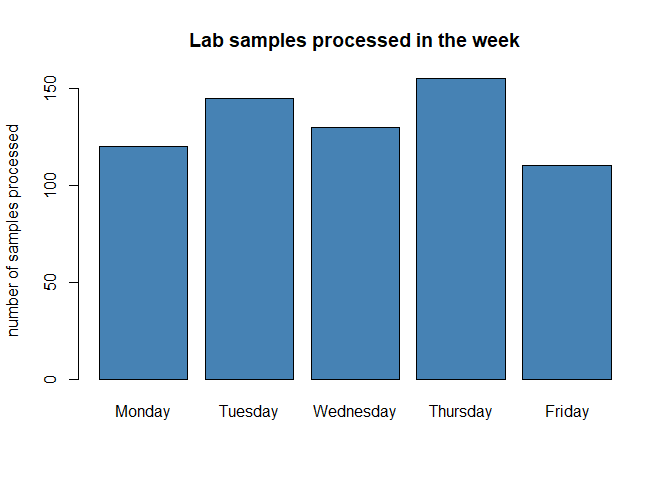

```r
barplot(barplot_data$samples_processed,
        names = barplot_data$day,
        col = "steelblue",
        main = "Lab samples processed in the week",
        ylab = "number of samples processed")
```

Now the same with the larger dataset:

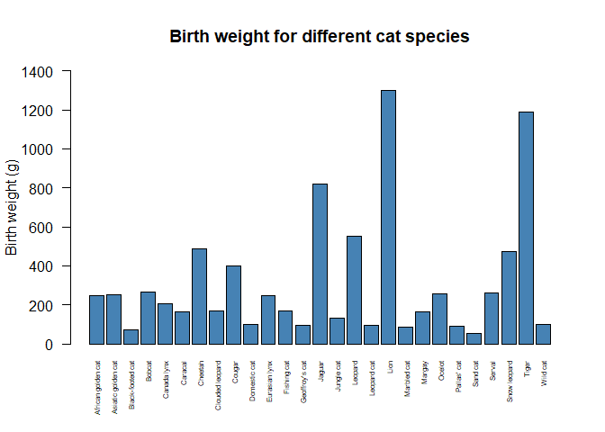

```r
barplot(summ_data$`Birth weight (g)`,
        ylab = "Birth weight (g)",
        ylim = c(0, max(summ_data$`Birth weight (g)` + 100)),
        names = summ_data$`Common name`,
        las = 2,
        cex.names = 0.5,
        col = "steelblue",
        main = "Birth weight for different cat species")
```

As you can see, it worked but the plot is not very aesthetically pleasing. Also, the bar labels are to small to properly read but if they are scaled to a bigger size, they will fall of the plot area and will be truncated. Now let’s compare this with the same type of plot using the same data but now the plot will be created in ggplot2.

## Bar Chart in ggplot2

First we will create the barplot_data in ggplot:

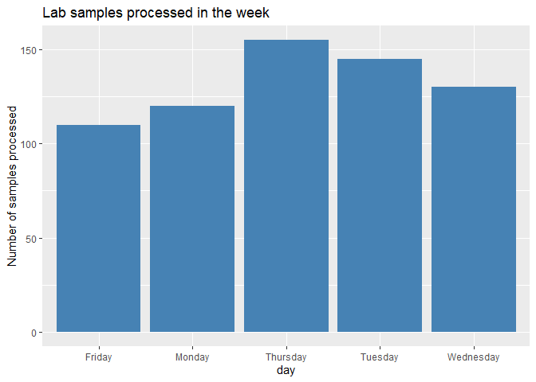

```r
p <- barplot_data %>%
  ggplot(aes(x = day, y = samples_processed)) +
  geom_bar(stat="identity", fill="steelblue") +
  labs(title="Lab samples processed in the week", y = "Number of samples processed")
p
```

And now the barplot of the larger dataset:

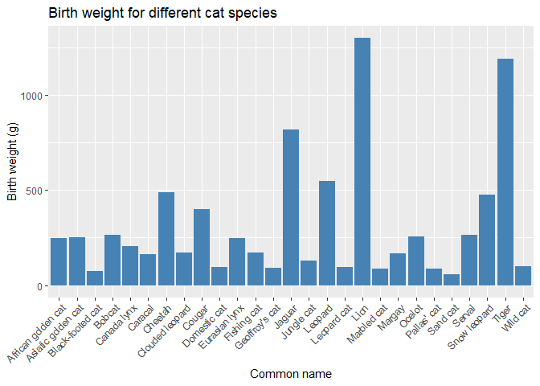

```r
p <- summ_data %>%
  ggplot(aes(x = `Common name`, y = `Birth weight (g)`)) +
  geom_bar(stat="identity", fill="steelblue") +
  labs(title="Birth weight for different cat species") +
  theme(axis.text.x = element_text(angle = 45, hjust=1)) #rotate the x-axis labels 45 degrees
p
```

Plotting with ggplot2 is much more flexible and the plots created are very aesthetically pleasing (although this may be subjective). From the graph it is clear that the `Tiger` and `Lion` have the highest birth weight.

## Grouped bar chart

We will start with a simple example for a grouped bar chart.  
Consider the following data:

```r
grouped_bar_data <- tibble(
cell_line = c("HEK293", "HEK293", "HeLa", "HeLa", "MCF7", "MCF7"),
protein = c("Protein X", "Protein Y", "Protein X", "Protein Y", "Protein X", "Protein Y"),
concentration = c(12.4, 8.2, 15.1, 14.3, 6.8, 19.5))
formatted_table(head(grouped_bar_data))
```

| cell_line chr | protein chr | concentration dbl |
| --- | --- | --- |
| HEK293 | Protein X | 12.4 |
| HEK293 | Protein Y | 8.2 |
| HeLa | Protein X | 15.1 |
| HeLa | Protein Y | 14.3 |
| MCF7 | Protein X | 6.8 |
| MCF7 | Protein Y | 19.5 |

And now we create a simple barplot:

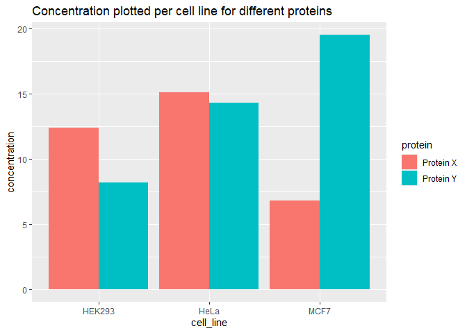

```r
p <- grouped_bar_data %>%
  ggplot(aes(x = cell_line, y = concentration, fill = protein)) +
  geom_bar(stat = "identity", position="dodge") +
  labs(title="Concentration plotted per cell line for different proteins")
p
```

Now let us look at the weight of newborns compared to the weight of the adults in one bar graph. Remember from the example in Excel that the logarithmic scale was used for the y-axis.

The first thing we do is to make the data tidy:

```r
tidy_summ_data <- summ_data %>%
  pivot_longer(c(`Birth weight (g)`, `Adult weight (g)`), names_to = "Weight type", values_to = "Weight (g)")
formatted_table(head(tidy_summ_data))
```

| Family chr | Common name chr | Weight type chr | Weight (g) dbl |
| --- | --- | --- | --- |
| Felidae | African golden cat | Birth weight (g) | 248.33 |
| Felidae | African golden cat | Adult weight (g) | 10650.00 |
| Felidae | Asiatic golden cat | Birth weight (g) | 250.00 |
| Felidae | Asiatic golden cat | Adult weight (g) | 13500.00 |
| Felidae | Black-footed cat | Birth weight (g) | 72.40 |
| Felidae | Black-footed cat | Adult weight (g) | 2125.00 |

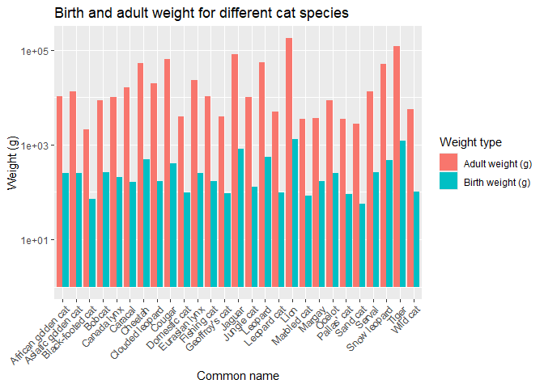

```r
p <- tidy_summ_data %>%
  ggplot(aes(x = `Common name`, y = `Weight (g)`, fill = `Weight type`)) +
  geom_bar(stat = "identity", position="dodge") +
  scale_y_log10() +
  labs(title="Birth and adult weight for different cat species", y = "Weight (g)") +
  theme(axis.text.x = element_text(angle = 45, hjust=1))
p
```

## Stacked bar chart

Creating a stacked bar chart is easy. Just change the `position` argument to “stack” (or omit it altogether as it is the default parameter, but there is nothing wrong in being explicit):

For the simple example:

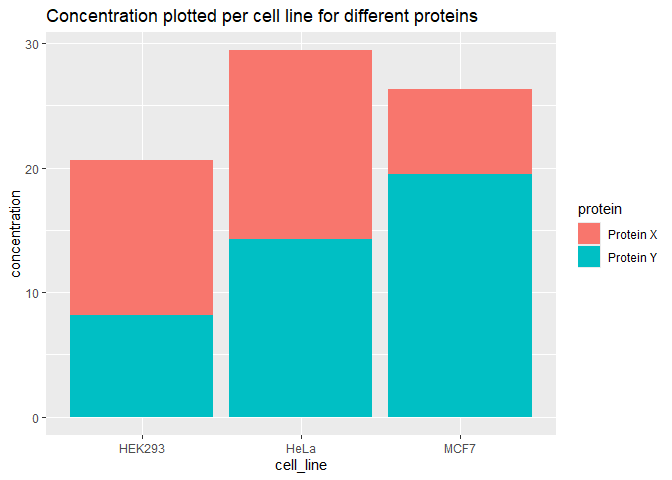

```r
p <- grouped_bar_data %>%
  ggplot(aes(x = cell_line, y = concentration, fill = protein)) +
  geom_bar(stat = "identity", position="stack") +
  labs(title="Concentration plotted per cell line for different proteins")
p
```

A stacked column chart should only be used when the individual values combine to form a meaningful total. For example, it is not meaningful to plot birth weight and adult weight for different cat species in a stacked column chart. To demonstrate a meaningful use of a stacked column chart we will use another (fictional) dataset on the average feeding data for big cats in a zoo. In this chart, each column represents a species, and the segments within each column show the contribution of different food components (such as meat, bone, and supplements) to the total daily diet.

```r
cat_diet <- read_csv("./files_12_data_visualization/file01_dataset_ zoo_big_cat_feeding.csv")
formatted_table(cat_diet)
```

| Species chr | Meat_kg_per_day_per_animal dbl | Bone_kg_per_day_per_animal dbl | Supplements_kg_per_day_per_animal dbl |
| --- | --- | --- | --- |
| Lion | 6.50 | 1.07 | 0.21 |
| Tiger | 7.10 | 1.10 | 0.29 |
| Leopard | 4.23 | 0.77 | 0.20 |
| Cheetah | 3.23 | 0.47 | 0.10 |

Before we create the graph, we need to re-arrange the data in tidy format:

```r
cat_diet_tidy <- cat_diet %>%
  select(
    Species,
    Meat = Meat_kg_per_day_per_animal,
    Bone = Bone_kg_per_day_per_animal,
    Supplements = Supplements_kg_per_day_per_animal) %>%
  pivot_longer(
    cols = c(Meat, Bone, Supplements),
    names_to = "Component",
    values_to = "Value"
  )

formatted_table(cat_diet_tidy)
```

| Species chr | Component chr | Value dbl |
| --- | --- | --- |
| Lion | Meat | 6.50 |
| Lion | Bone | 1.07 |
| Lion | Supplements | 0.21 |
| Tiger | Meat | 7.10 |
| Tiger | Bone | 1.10 |
| Tiger | Supplements | 0.29 |
| Leopard | Meat | 4.23 |
| Leopard | Bone | 0.77 |
| Leopard | Supplements | 0.20 |
| Cheetah | Meat | 3.23 |
| Cheetah | Bone | 0.47 |
| Cheetah | Supplements | 0.10 |

And now we can create the stacked barplot:

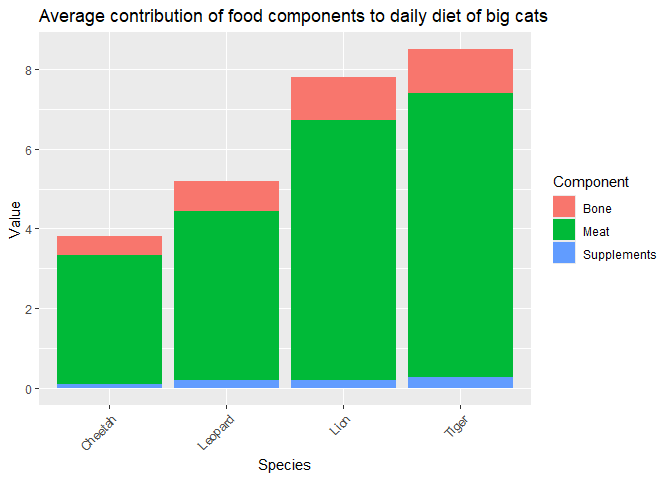

```r
p <- cat_diet_tidy %>%
  ggplot(aes(x = `Species`, y = `Value`, fill = `Component`)) +
  geom_bar(stat = "identity", position="stack") +
  labs(title="Average contribution of food components to daily diet of big cats") +
  theme(axis.text.x = element_text(angle = 45, hjust=1))
p
```

## Percent stacked barchart

A percent (actually a fraction) stacked barchart can be created by changing the `position` argument to “fill”:

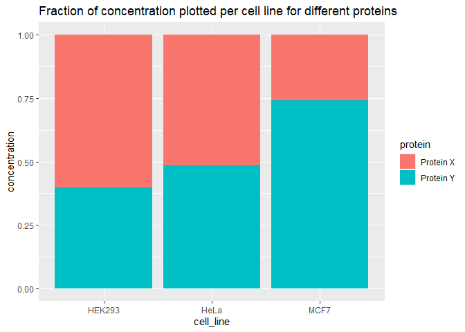

```r
p <- grouped_bar_data %>%
  ggplot(aes(x = cell_line, y = concentration, fill = protein)) +
  geom_bar(stat = "identity", position="fill") +
  labs(title="Fraction of concentration plotted per cell line for different proteins")
p
```

And for the more elaborate dataset:

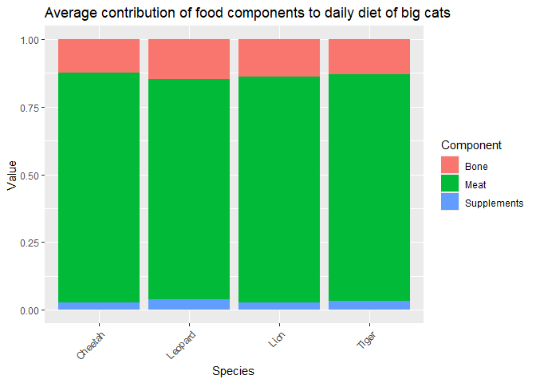

```r
p <- cat_diet_tidy %>%
  ggplot(aes(x = `Species`, y = `Value`, fill = `Component`)) +
  geom_bar(stat = "identity", position="fill") +
  labs(title="Average contribution of food components to daily diet of big cats") +
  theme(axis.text.x = element_text(angle = 45, hjust=1))
p
```

## Switch order of groups

If you want to change the order of groups you will need to change the column from character to a factor as factors do support levels: And we can change the order of levels accordingly:

```r
tidy_summ_data <- tidy_summ_data %>%
  mutate(`Weight type` = factor(`Weight type`, levels = c("Birth weight (g)", "Adult weight (g)")))
formatted_table(head(tidy_summ_data))
```

| Family chr | Common name chr | Weight type fct | Weight (g) dbl |
| --- | --- | --- | --- |
| Felidae | African golden cat | Birth weight (g) | 248.33 |
| Felidae | African golden cat | Adult weight (g) | 10650.00 |
| Felidae | Asiatic golden cat | Birth weight (g) | 250.00 |
| Felidae | Asiatic golden cat | Adult weight (g) | 13500.00 |
| Felidae | Black-footed cat | Birth weight (g) | 72.40 |
| Felidae | Black-footed cat | Adult weight (g) | 2125.00 |

As you can see, the order of the levels is swapped.

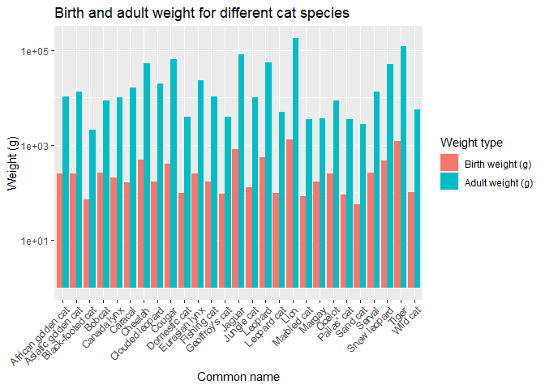

```r
p <- tidy_summ_data %>%
  ggplot(aes(x = `Common name`, y = `Weight (g)`, fill = `Weight type`)) +
  geom_bar(stat = "identity", position="dodge") +
  scale_y_log10() +
  labs(title="Birth and adult weight for different cat species") +
  theme(axis.text.x = element_text(angle = 45, hjust=1))
p
```

The same can be done for the stacked barchart:

```r
cat_diet_tidy_ordered <- cat_diet_tidy %>%
  mutate(Component = factor(Component, levels = c("Supplements", "Bone", "Meat")))
formatted_table(cat_diet_tidy_ordered)
```

| Species chr | Component fct | Value dbl |
| --- | --- | --- |
| Lion | Meat | 6.50 |
| Lion | Bone | 1.07 |
| Lion | Supplements | 0.21 |
| Tiger | Meat | 7.10 |
| Tiger | Bone | 1.10 |
| Tiger | Supplements | 0.29 |
| Leopard | Meat | 4.23 |
| Leopard | Bone | 0.77 |
| Leopard | Supplements | 0.20 |
| Cheetah | Meat | 3.23 |
| Cheetah | Bone | 0.47 |
| Cheetah | Supplements | 0.10 |

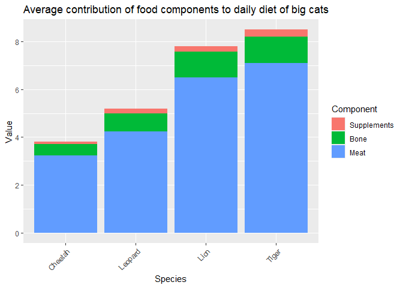

```r
p <- cat_diet_tidy_ordered %>%
  ggplot(aes(x = `Species`, y = `Value`, fill = `Component`)) +
  geom_bar(stat = "identity", position="stack") +
  labs(title="Average contribution of food components to daily diet of big cats") +
  theme(axis.text.x = element_text(angle = 45, hjust=1))
p
```

And the 100% stacked barchart:

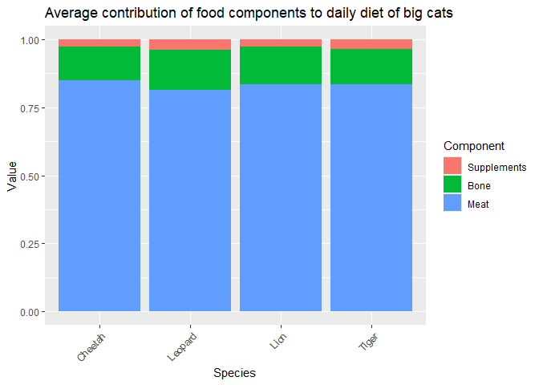

```r
p <- cat_diet_tidy_ordered %>%
  ggplot(aes(x = `Species`, y = `Value`, fill = `Component`)) +
  geom_bar(stat = "identity", position="fill") +
  labs(title="Average contribution of food components to daily diet of big cats") +
  theme(axis.text.x = element_text(angle = 45, hjust=1))
p
```

## Pie Chart

Pie charts are suitable for displaying data that can be broken down into categories or parts that add up to a whole. They are often used to show proportions or percentages of a whole.

First a simple example:

```r
pie_chart_data <- tibble(
  cell_type = c("Neutrophils", "Lymphocytes", "Monocytes", "Eosinophils", "Basophils"),
  percentage = c(60, 25, 8, 5, 2)
)
formatted_table(head(pie_chart_data))
```

| cell_type chr | percentage dbl |
| --- | --- |
| Neutrophils | 60 |
| Lymphocytes | 25 |
| Monocytes | 8 |
| Eosinophils | 5 |
| Basophils | 2 |

And the corresponding Pie chart:

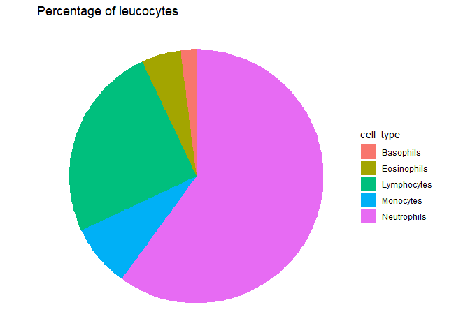

```r
p <- pie_chart_data %>%
  ggplot(aes(x = "", y = percentage, fill = cell_type)) +
  geom_bar(stat="identity", width=1) +
  coord_polar("y", start=0) +
  labs(title="Percentage of leucocytes") +
  theme_void() # remove background, grid, numeric labels
p
```

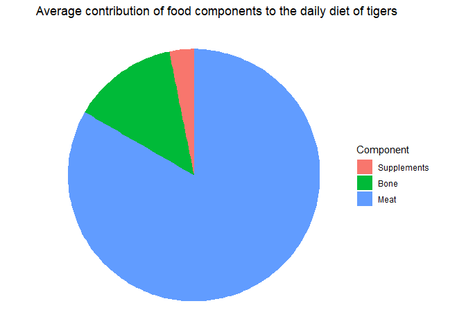

```r
p <- cat_diet_tidy_ordered %>%
  ggplot(aes(x = "", y = `Value`, fill = `Component`)) +
  geom_bar(stat="identity", width=1) +
  coord_polar("y", start=0) +
  labs(title="Average contribution of food components to the daily diet of tigers") +
  theme_void() # remove background, grid, numeric labels
p
```

## Radar Charts

Like Excel, radar charts can be created in R. The same data set will be used as shown in the Excel section.

```r
file_path <- "./files_12_data_visualization/file02_radar_data.csv"
rest_data <- read.csv2(file_path, check.names = F)
formatted_table(rest_data)
```

| Row Labels chr | Sample 1 int | Sample 2 int | Sample 3 dbl |
| --- | --- | --- | --- |
| Lowry | 240 | 266 | 146.5 |
| Bradford | 260 | 265 | 138.5 |
| BCA | 254 | 254 | 139.0 |
| UV/VIS | 276 | 266 | 149.0 |
| Kjedahl | 567 | 534 | 268.5 |

But before we can create a radar plot we need to transpose the data frame.  
The category items will be the variables (or features) and hence, need to be in columns.  
The different samples will be the records (or observations) and need to be organized in rows.  
You can find an example in the data cleaning section.

```r
trans_matrix <- t(rest_data)
trans_matrix
```

```
##            [,1]    [,2]       [,3]    [,4]     [,5]
## Row Labels "Lowry" "Bradford" "BCA"   "UV/VIS" "Kjedahl"
## Sample 1   "240"   "260"      "254"   "276"    "567"
## Sample 2   "266"   "265"      "254"   "266"    "534"
## Sample 3   "146.5" "138.5"    "139.0" "149.0"  "268.5"
```

> It is possible to use the `pivot_longer()` and `pivot_wider()` functions to transpose a tibble but we find it easier to understand in base R.  
> Hence we use base R for this.

Convert it to a tibble:

```r
trans_tibble <- tibble(data.frame(trans_matrix))
formatted_table((trans_tibble))
```

| X1 chr | X2 chr | X3 chr | X4 chr | X5 chr |
| --- | --- | --- | --- | --- |
| Lowry | Bradford | BCA | UV/VIS | Kjedahl |
| 240 | 260 | 254 | 276 | 567 |
| 266 | 265 | 254 | 266 | 534 |
| 146.5 | 138.5 | 139.0 | 149.0 | 268.5 |

And then do some cleaning:

```r
colnames(trans_tibble) <- trans_tibble[1, ] # first row will be column names
trans_tibble <- trans_tibble[-1, ] # delete first row
trans_tibble <- trans_tibble %>%
  mutate(across(everything(), as.numeric)) %>% # make all columns numeric
  mutate(Sample = c("Sample 1", "Sample 2", "Sample 3"), .before=1)
formatted_table(trans_tibble)
```

| Sample chr | Lowry dbl | Bradford dbl | BCA dbl | UV/VIS dbl | Kjedahl dbl |
| --- | --- | --- | --- | --- | --- |
| Sample 1 | 240.0 | 260.0 | 254 | 276 | 567.0 |
| Sample 2 | 266.0 | 265.0 | 254 | 266 | 534.0 |
| Sample 3 | 146.5 | 138.5 | 139 | 149 | 268.5 |

The last thing we need to do is to scale the data to numbers ranging from 0-1:

```r
rest_data_scaled <- trans_tibble[, -1]/1000
formatted_table(rest_data_scaled)
```

| Lowry dbl | Bradford dbl | BCA dbl | UV/VIS dbl | Kjedahl dbl |
| --- | --- | --- | --- | --- |
| 0.2400 | 0.2600 | 0.254 | 0.276 | 0.5670 |
| 0.2660 | 0.2650 | 0.254 | 0.266 | 0.5340 |
| 0.1465 | 0.1385 | 0.139 | 0.149 | 0.2685 |

Get the first column:

```r
first_col <- trans_tibble[, 1]
formatted_table(first_col)
```

| Sample chr |
| --- |
| Sample 1 |
| Sample 2 |
| Sample 3 |

And combine the two tibbles:

```r
rest_data <- cbind(first_col, rest_data_scaled)
formatted_table(rest_data)
```

| Sample chr | Lowry dbl | Bradford dbl | BCA dbl | UV/VIS dbl | Kjedahl dbl |
| --- | --- | --- | --- | --- | --- |
| Sample 1 | 0.2400 | 0.2600 | 0.254 | 0.276 | 0.5670 |
| Sample 2 | 0.2660 | 0.2650 | 0.254 | 0.266 | 0.5340 |
| Sample 3 | 0.1465 | 0.1385 | 0.139 | 0.149 | 0.2685 |

And now we can build the radar plot.

We first need to install a ggplot2 extension:

Run the following code to install the module:

```
install.packages("remotes")
remotes::install_github("ricardo-bion/ggradar")
```

Now load the module:

```r
library(ggradar)
```

And now we can create a radar chart:

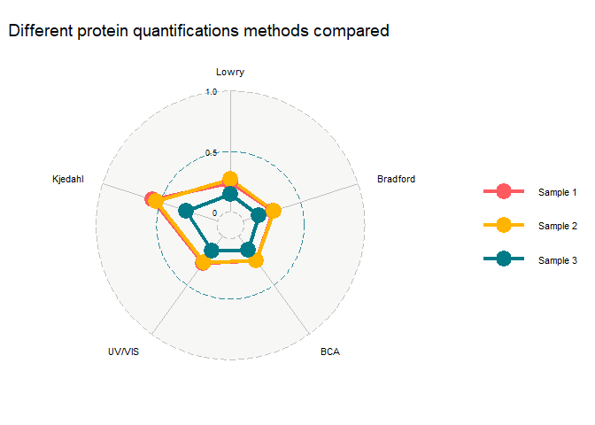

```r
p <- rest_data %>%
  ggradar(legend.text.size = 8, values.radar = c("0", "0.5", "1.0"), axis.label.size = 3, grid.label.size = 3, legend.position = "right") +
  labs(title = "Different protein quantifications methods compared") +
  theme(plot.title = element_text(size = 14, ))
p
```

That was actually quite a lot of work…

## Boxplots

Fortunately, creating box plots in ggplots2 is easier.

First let’s use a simple example:

```r
boxplot_data <- tibble(
condition = c(rep("Control", 5), rep("Treatment A", 5), rep("Treatment B", 5)),
expression_level = c(4.2, 4.5, 3.8, 4.1, 5.0, 7.1, 6.8, 7.5, 8.2, 6.9, 2.1, 2.5, 1.8, 3.0, 2.2)
)
formatted_table(boxplot_data)
```

| condition chr | expression_level dbl |
| --- | --- |
| Control | 4.2 |
| Control | 4.5 |
| Control | 3.8 |
| Control | 4.1 |
| Control | 5.0 |
| Treatment A | 7.1 |
| Treatment A | 6.8 |
| Treatment A | 7.5 |
| Treatment A | 8.2 |
| Treatment A | 6.9 |
| Treatment B | 2.1 |
| Treatment B | 2.5 |
| Treatment B | 1.8 |
| Treatment B | 3.0 |
| Treatment B | 2.2 |

And now a simple boxplot example:

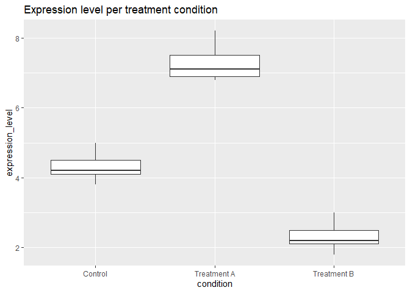

```r
p <- boxplot_data %>% ggplot(aes(x = condition, y = expression_level)) +
  geom_boxplot() +
  labs(title="Expression level per treatment condition")
p
```

We will take the same data set as earlier and select only the order Artiodactyla (pig, sheep, giraffe, deer, etc.):

```r
file_path <- "./files_12_data_visualization/file01_anage_data.csv"
df <- read.csv2(file_path, check.names = F)
formatted_table(head(df))
```

| HAGRID int | Kingdom chr | Phylum chr | Class chr | Order chr | Family chr | Genus chr | Species chr | Common name chr | Female maturity (days) int | Male maturity (days) int | Gestation/Incubation (days) int | Weaning (days) int | Litter/Clutch size chr | Litters/Clutches per year chr | Inter-litter/Interbirth interval int | Birth weight (g) chr | Weaning weight (g) chr | Adult weight (g) chr | Growth rate (1/days) chr | Maximum longevity (yrs) chr | Source chr | Specimen origin chr | Sample size chr | Data quality chr | IMR (per yr) chr | MRDT (yrs) chr | Metabolic rate (W) chr | Body mass (g) chr | Temperature (K) chr | … |
| --- | --- | --- | --- | --- | --- | --- | --- | --- | --- | --- | --- | --- | --- | --- | --- | --- | --- | --- | --- | --- | --- | --- | --- | --- | --- | --- | --- | --- | --- | --- |
| 3 | Animalia | Annelida | Polychaeta | Sabellida | Siboglinidae | Escarpia | laminata | Escarpia laminata | NA | NA | NA | NA |  |  | NA |  |  |  |  | 300 | 1466 | wild | medium | acceptable |  |  |  |  |  | … |
| 5 | Animalia | Annelida | Polychaeta | Sabellida | Siboglinidae | Lamellibrachia | luymesi | Lamellibrachia luymesi | NA | NA | NA | NA |  |  | NA |  |  |  |  | 250 | 652 | wild | small | acceptable |  |  |  |  |  | … |
| 6 | Animalia | Annelida | Polychaeta | Sabellida | Siboglinidae | Seepiophila | jonesi | Seepiophila jonesi | NA | NA | NA | NA |  |  | NA |  |  |  |  | 300 | 1467 | wild | small | acceptable |  |  |  |  |  | … |
| 8 | Animalia | Arthropoda | Arachnida | Araneae | Theridiidae | Latrodectus | hasselti | Australian redback spider | NA | NA | NA | NA |  |  | NA |  |  |  |  |  |  | unknown | medium | low |  |  |  |  |  | … |
| 9 | Animalia | Arthropoda | Branchiopoda | Diplostraca | Daphniidae | Daphnia | pulicaria | Daphnia | NA | NA | NA | NA |  |  | NA |  |  |  |  | 0.19 |  | unknown | medium | acceptable |  |  |  |  |  | … |
| 11 | Animalia | Arthropoda | Insecta | Diptera | Drosophilidae | Drosophila | melanogaster | Fruit fly | 7 | 7 | NA | NA |  |  | NA |  |  |  |  | 0.3 |  | captivity | large | acceptable | 0.05 | 0.04 |  |  |  | … |

And now prep the tibble:

```r
artiod_df <- df %>%
  filter(Order == "Artiodactyla") %>%
  arrange(`Common name`) %>%
  select(Order, Family, `Common name`, `Maximum longevity (yrs)`, `Adult weight (g)`, `Birth weight (g)`) %>%
  mutate(`Maximum longevity (yrs)` = as.numeric(`Maximum longevity (yrs)`)) %>%
  mutate(`Adult weight (g)` = as.numeric(`Adult weight (g)`)) %>%
  mutate(`Birth weight (g)` = as.numeric(`Birth weight (g)`)) %>%
  drop_na()
formatted_table(head(artiod_df))
```

| Order chr | Family chr | Common name chr | Maximum longevity (yrs) dbl | Adult weight (g) dbl | Birth weight (g) dbl |
| --- | --- | --- | --- | --- | --- |
| Artiodactyla | Bovidae | Addax | 28.0 | 92500 | 5600 |
| Artiodactyla | Bovidae | African buffalo | 32.8 | 700000 | 44000 |
| Artiodactyla | Camelidae | Alpaca | 25.8 | 62000 | 7210 |
| Artiodactyla | Bovidae | American bison | 33.5 | 630000 | 20000 |
| Artiodactyla | Bovidae | Aoudad | 21.7 | 92500 | 4500 |
| Artiodactyla | Bovidae | Argali | 16.8 | 160000 | 3400 |

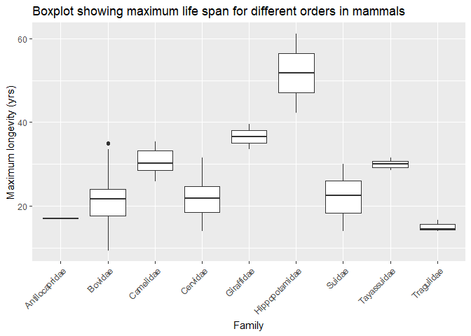

```r
p <- artiod_df %>% ggplot(aes(x = `Family`, y = `Maximum longevity (yrs)`)) +
  geom_boxplot() +
  labs(title="Boxplot showing maximum life span for different orders in mammals") +
  theme(axis.text.x = element_text(angle = 45, hjust=1))
p
```

It seems that the hippo has the longest life span among the Artiodactyla.

## Grouped box plots

For a simple example of grouped box plot we can adjust the previous mini dataset:

```r
grouped_boxplot_data <- tibble(
  condition = c(rep("Control", 6), rep("Treatment X", 6), rep("Treatment Y", 6)),
  gene = rep(c("Gene A", "Gene A", "Gene A", "Gene B", "Gene B", "Gene B"), 3),
  expression_level = c(4.2, 4.5, 3.8, 2.1, 2.5, 1.9, 7.1, 6.8, 7.5, 5.4, 5.1, 5.9, 2.1, 2.5, 1.8, 8.2, 8.9, 8.5)
)
formatted_table(grouped_boxplot_data)
```

| condition chr | gene chr | expression_level dbl |
| --- | --- | --- |
| Control | Gene A | 4.2 |
| Control | Gene A | 4.5 |
| Control | Gene A | 3.8 |
| Control | Gene B | 2.1 |
| Control | Gene B | 2.5 |
| Control | Gene B | 1.9 |
| Treatment X | Gene A | 7.1 |
| Treatment X | Gene A | 6.8 |
| Treatment X | Gene A | 7.5 |
| Treatment X | Gene B | 5.4 |
| Treatment X | Gene B | 5.1 |
| Treatment X | Gene B | 5.9 |
| Treatment Y | Gene A | 2.1 |
| Treatment Y | Gene A | 2.5 |
| Treatment Y | Gene A | 1.8 |
| Treatment Y | Gene B | 8.2 |
| Treatment Y | Gene B | 8.9 |
| Treatment Y | Gene B | 8.5 |

And create the boxplot:

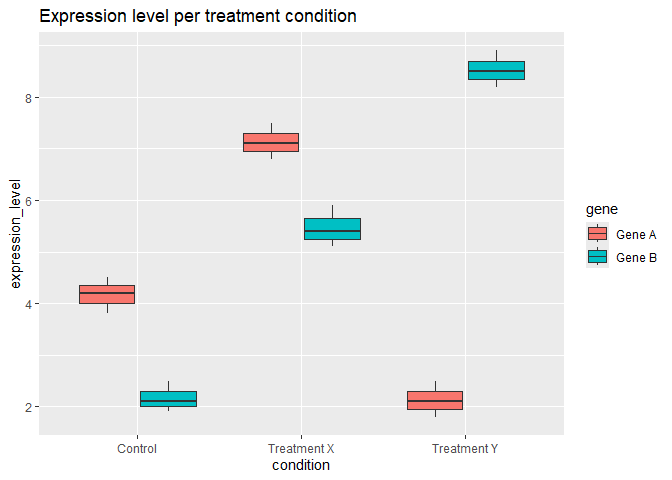

```r
p <- grouped_boxplot_data %>% ggplot(aes(x = condition, y = expression_level, fill = gene)) +
  geom_boxplot() +
  labs(title="Expression level per treatment condition")
p
```

```r
tidy_artiod <- artiod_df %>%
  pivot_longer(c(`Birth weight (g)`, `Adult weight (g)`), names_to = "Weight type", values_to = "Weight (g)")
formatted_table(head(tidy_artiod))
```

| Order chr | Family chr | Common name chr | Maximum longevity (yrs) dbl | Weight type chr | Weight (g) dbl |
| --- | --- | --- | --- | --- | --- |
| Artiodactyla | Bovidae | Addax | 28.0 | Birth weight (g) | 5600 |
| Artiodactyla | Bovidae | Addax | 28.0 | Adult weight (g) | 92500 |
| Artiodactyla | Bovidae | African buffalo | 32.8 | Birth weight (g) | 44000 |
| Artiodactyla | Bovidae | African buffalo | 32.8 | Adult weight (g) | 700000 |
| Artiodactyla | Camelidae | Alpaca | 25.8 | Birth weight (g) | 7210 |
| Artiodactyla | Camelidae | Alpaca | 25.8 | Adult weight (g) | 62000 |

And now create the grouped box plot:

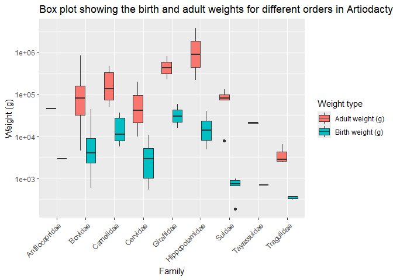

```r
p <- tidy_artiod %>%
  ggplot(aes(x = `Family`, y = `Weight (g)`, fill = `Weight type`)) +
  geom_boxplot() +
  scale_y_log10() +
  labs(title="Box plot showing the birth and adult weights for different orders in Artiodactyla") +
  theme(axis.text.x = element_text(angle = 45, hjust=1))
p
```

Again, if you want to swap the order of the groups you can change the character columns to factors:

```r
tidy_artiod <- tidy_artiod %>%
  mutate(`Weight type` = factor(`Weight type`, levels = c("Birth weight (g)", "Adult weight (g)")))
formatted_table(head(tidy_artiod))
```

| Order chr | Family chr | Common name chr | Maximum longevity (yrs) dbl | Weight type fct | Weight (g) dbl |
| --- | --- | --- | --- | --- | --- |
| Artiodactyla | Bovidae | Addax | 28.0 | Birth weight (g) | 5600 |
| Artiodactyla | Bovidae | Addax | 28.0 | Adult weight (g) | 92500 |
| Artiodactyla | Bovidae | African buffalo | 32.8 | Birth weight (g) | 44000 |
| Artiodactyla | Bovidae | African buffalo | 32.8 | Adult weight (g) | 700000 |
| Artiodactyla | Camelidae | Alpaca | 25.8 | Birth weight (g) | 7210 |
| Artiodactyla | Camelidae | Alpaca | 25.8 | Adult weight (g) | 62000 |

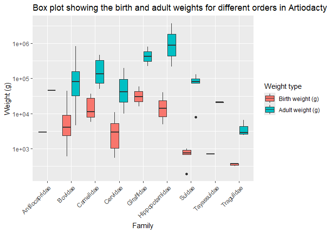

```r
p <- tidy_artiod %>%
  ggplot(aes(x = `Family`, y = `Weight (g)`, fill = `Weight type`)) +
  geom_boxplot() +
  scale_y_log10() +
  labs(title="Box plot showing the birth and adult weights for different orders in Artiodactyla") +
  theme(axis.text.x = element_text(angle = 45, hjust=1))
p
```

## Violin Charts

We start with a simple violin plot using our previous example:

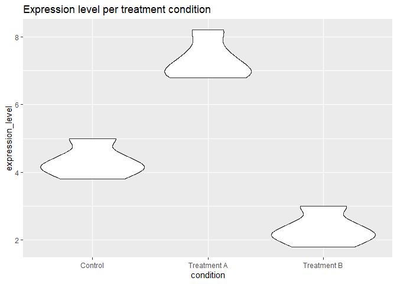

```r
p <- boxplot_data %>% ggplot(aes(x = condition, y = expression_level)) +
   geom_violin() +
  labs(title="Expression level per treatment condition")
p
```

Or using the grouped boxplot data example:

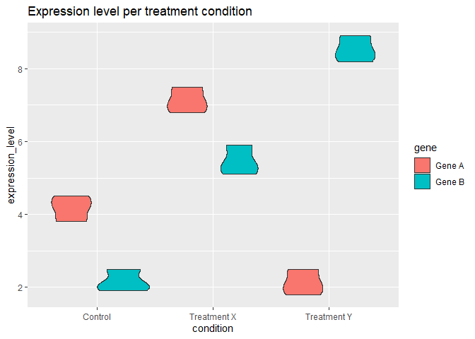

```r
p <- grouped_boxplot_data %>% ggplot(aes(x = condition, y = expression_level, fill = gene)) +
  geom_violin() +
  labs(title="Expression level per treatment condition")
p
```

Let’s show the animal longevity data as a violin plot (the Antilocapridae family is excluded, because it contains only one data point):

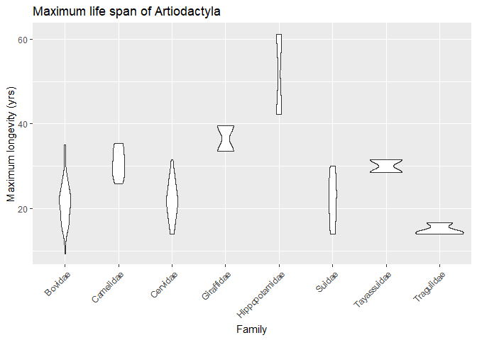

```r
artiod_df <- artiod_df %>%
  filter(Family != "Antilocapridae")
p <- artiod_df %>%
  ggplot(aes(x = `Family`, y = `Maximum longevity (yrs)`)) +
  geom_violin() +
  labs(title="Maximum life span of Artiodactyla") +
  theme(axis.text.x = element_text(angle = 45, hjust=1))
p
```

## Line plots

A line plot is a graph that displays information as a series of data points connected by line segments to show trends or changes over time or a continuous sequence.

Consider the following dataset:

```r
lab_data_single <- tibble(
  time_hours = c(0, 2, 4, 6, 8, 10),
  OD600      = c(0.05, 0.12, 0.35, 0.78, 1.24, 1.35)
)
formatted_table(head(lab_data_single))
```

| time_hours dbl | OD600 dbl |
| --- | --- |
| 0 | 0.05 |
| 2 | 0.12 |
| 4 | 0.35 |
| 6 | 0.78 |
| 8 | 1.24 |
| 10 | 1.35 |

And the corresponding line graph:

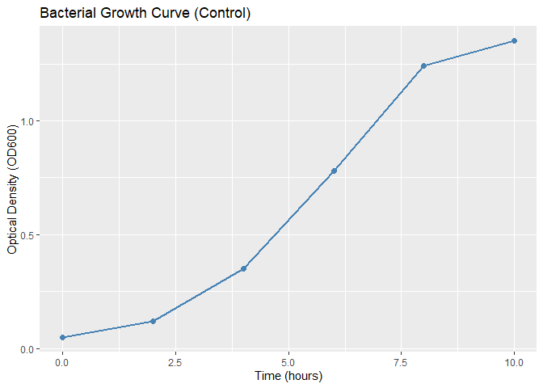

```r
p <- lab_data_single %>%
  ggplot(aes(x = time_hours, y = OD600)) +
  geom_line(linewidth = 1, color = "steelblue") +
  geom_point(size = 2, color = "steelblue") +
  labs(
    title = "Bacterial Growth Curve (Control)",
    x = "Time (hours)",
    y = "Optical Density (OD600)"
  )
p
```

And now an example of multiple series:

```r
lab_data_double <- tibble(
  time_hours = rep(c(0, 2, 4, 6, 8, 10), times = 2),
  condition  = rep(c("Control", "Treatment"), each = 6),
  OD600      = c(0.05, 0.12, 0.35, 0.78, 1.24, 1.35,  # Control groep
                 0.05, 0.09, 0.21, 0.45, 0.68, 0.72)   # Treatment groep
)
formatted_table(head(lab_data_double))
```

| time_hours dbl | condition chr | OD600 dbl |
| --- | --- | --- |
| 0 | Control | 0.05 |
| 2 | Control | 0.12 |
| 4 | Control | 0.35 |
| 6 | Control | 0.78 |
| 8 | Control | 1.24 |
| 10 | Control | 1.35 |

And the corresponding graph:

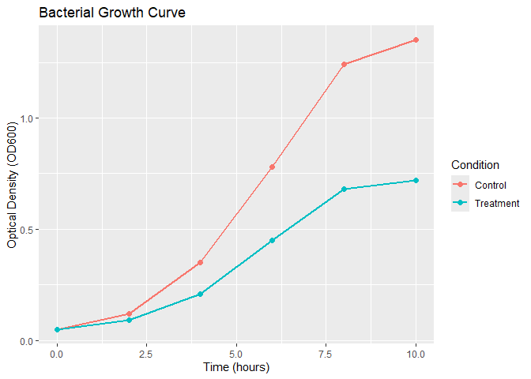

```r
p <- lab_data_double %>%
  ggplot(aes(x = time_hours, y = OD600, color = condition)) +
  geom_line(linewidth = 1) +
  geom_point(size = 2) +
  labs(
    title = "Bacterial Growth Curve",
    x = "Time (hours)",
    y = "Optical Density (OD600)",
    color = "Condition"
  )
p
```

As an example of a larger dataset, we take fictive data) about the OB/OB and DB/DB mice (compared to the wild type) and the gain of weight in these mice during a period of time as was used in the Excel section. The data is as follows and can be downloaded here:

```r
library(readxl)
file_path <- "./files_12_data_visualization/file_03_mouse_weight_data.xlsx"
mouse_weight <- read_excel(file_path)
formatted_table(head(mouse_weight))
```

| Date dttm | Wild-type dbl | OB/OB dbl | DB/DB dbl |
| --- | --- | --- | --- |
| 2020-01-01 | 20.00000 | 20.00000 | 20.00000 |
| 2020-01-02 | 20.00954 | 20.15443 | 20.11541 |
| 2020-01-03 | 19.89113 | 20.38395 | 20.19689 |
| 2020-01-04 | 20.05406 | 20.42536 | 20.28886 |
| 2020-01-05 | 20.26770 | 20.48577 | 20.36530 |
| 2020-01-06 | 20.46766 | 20.55731 | 20.59914 |

Note that the first column (<S3: POSIXct>) is a date-time format.

We first need to make the data tidy:

```r
tidy_mouse_weight <- mouse_weight %>%
  pivot_longer(c(`Wild-type`, `OB/OB`, `DB/DB`), names_to = "Mouse strain", values_to = "Weight (g)")
formatted_table(head(tidy_mouse_weight))
```

| Date dttm | Mouse strain chr | Weight (g) dbl |
| --- | --- | --- |
| 2020-01-01 | Wild-type | 20.00000 |
| 2020-01-01 | OB/OB | 20.00000 |
| 2020-01-01 | DB/DB | 20.00000 |
| 2020-01-02 | Wild-type | 20.00954 |
| 2020-01-02 | OB/OB | 20.15443 |
| 2020-01-02 | DB/DB | 20.11541 |

So now we can create a line plot:

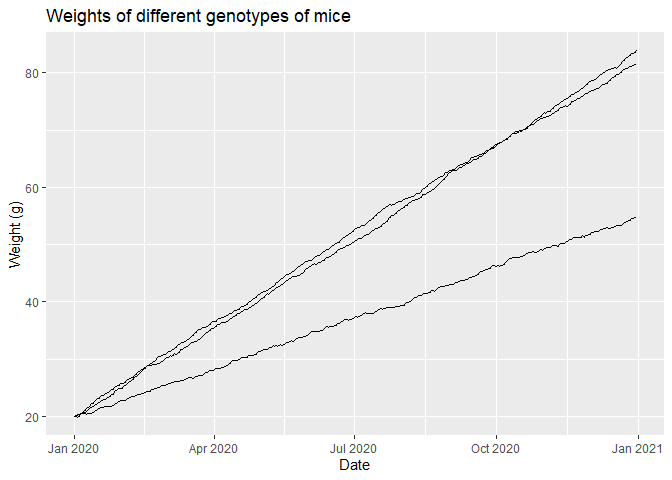

```r
p <- tidy_mouse_weight %>%
  ggplot(aes(x = Date, y = `Weight (g)`, group = `Mouse strain`)) +
  geom_line() +
  labs(title="Weights of different genotypes of mice")
p
```

As you can see, all lines in the group do have the same type and color.

We can either discriminate by type/shape:

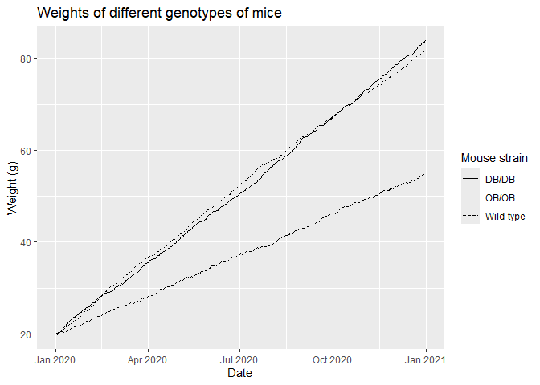

```r
p <- tidy_mouse_weight %>%
  ggplot(aes(x = Date, y = `Weight (g)`, group = `Mouse strain`)) +
  geom_line(aes(linetype = `Mouse strain`)) +
  labs(title="Weights of different genotypes of mice")
p
```

Or by color:

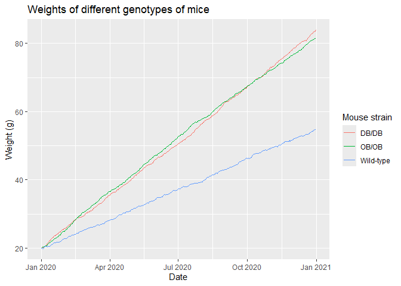

```r
p <- tidy_mouse_weight %>%
  ggplot(aes(x = Date, y = `Weight (g)`, group = `Mouse strain`)) +
  geom_line(aes(color = `Mouse strain`)) +
  labs(title="Weights of different genotypes of mice")
p
```